# Research question 3: If we use our own recommendations to compute ESCS, does this change the relationship between ESCS and the cognitive variables?

Kirsten van Kessel

2024-06-17

### Research question 3

In this document, we perform the analyses needed to investigate research question 3: If we use our own recommendations to compute ESCS, does this change the relationship between ESCS and the cognitive variables? We answer this question by first performing a regression with the original ESCS Then, we perform the analysis with a newly computed ESCS (ESCS_c). This ESCS is based on exploratory analysis on indicator level (multigroup CFA and imputation simulation). We also perform the analysis with another newly computed ESCS (ESCS_c_item). This ESCS is based on exploratory analysis on item level (IRT analysis).

#### Setup

We load the original data.

```r
# load libraries
library(haven)
library(dplyr)
library(tidyr)
library(mice)
library(missMethods)
library(ggplot2)
library(countrycode)
library(broom)
library(lme4)
library(dexterMML)
library(ggcorrplot)
library(lavaan)
library(tidyverse)
library(labelled)
library(janitor)
library(readxl)
library(knitr)
library(dexter)

# load data
data <- read_sav("../data/CY07_MSU_STU_QQQ.sav")
head(data)

# set seed
set.seed(679)

# scale indicators
data$HISEI <- as.numeric(scale(data$HISEI))
data$HOMEPOS <- as.numeric(scale(data$HOMEPOS))
data$PAREDINT <- as.numeric(scale(data$PAREDINT))
```

#### Create “original” MATH

```r
# use script PISA_2018_mathematics to create database

# load database
pisa18_m <- readRDS("../data/pisa18_m.RDS")

# select all plausible values of reading and the new ESCS
data_read <- data %>%
  select(CNTSTUID, ESCS, starts_with("PV")) %>%
  select(CNTSTUID, ESCS, ends_with("READ"))

# merge with cognitive data
pisa18_m <- merge(pisa18_m, data_read, by = "CNTSTUID")

# prepare for plausible_values()
colnames(pisa18_m)[colnames(pisa18_m) == "ESCS.y"] <- "ESCS"
colnames(pisa18_m)[colnames(pisa18_m) == "CNTSTUID"] <- "person_id"
colnames(pisa18_m)[colnames(pisa18_m) == "BOOKID"] <- "booklet_id"
pisa18_responses <- pisa18_m %>%
  select(person_id, item_id, item_score, booklet_id, ESCS, PV1READ) %>%
  drop_na(item_score) %>%
  unique()

# compute plausible values
PV_MATH <- dexter::plausible_values(pisa18_responses, covariates = c("ESCS", "PV1READ"), nPV = 10)
```

#### Regression original ESCS

```r
# create 10 SEM models
model1 <- "
PV1 ~ 1 + ESCS
"

model2 <- "
PV2 ~ 1 + ESCS
"

model3 <- "
PV3 ~ 1 + ESCS
"

model4 <- "
PV4 ~ 1 + ESCS
"

model5 <- "
PV5 ~ 1 + ESCS
"

model6 <- "
PV6 ~ 1 + ESCS
"

model7 <- "
PV7 ~ 1 + ESCS
"

model8 <- "
PV8 ~ 1 + ESCS
"

model9 <- "
PV9 ~ 1 + ESCS
"

model10 <- "
PV10 ~ 1 + ESCS
"

models <- c(model1, model2, model3, model4, model5, model6, model7, model8, model9, model10)
reg_coef <- c(rep(0,10))
p_value <- c(rep(0,10))

# fit SEM models
for(model in models){
  fit <- sem(model, data=PV_MATH)
  B <- summary(fit)[[5]]$est[2] # regression coefficient
  P <- summary(fit)[[5]]$pvalue[2] # pvalue
  reg_coef[match(model,models)] <- B
  p_value[match(model,models)] <- P
}

# mean regression coefficient
mean(reg_coef)
```

```
## [1] 0.4199403
```

```r
# mean p-value
mean(p_value)
```

```
## [1] 0
```

#### Create “PISAranking” (ranking we can compare other rankings to)

```r
# add CNT to PV_MATH
data_CNT <- data %>%
  select(CNTSTUID, CNT)
colnames(data_CNT)[colnames(data_CNT) == "CNTSTUID"] <- "person_id"
PV_MATH <- merge(PV_MATH, data_CNT, by = "person_id")

# make the original PISA ranking
MATH_mean <- PV_MATH %>% group_by(CNT) %>%
  summarize(mean1 = mean(PV1), mean2 = mean(PV2),
            mean3 = mean(PV3), mean4 = mean(PV4),
            mean5 = mean(PV5), mean6 = mean(PV6),
            mean7 = mean(PV7), mean8 = mean(PV8),
            mean9 = mean(PV9), mean10 = mean(PV10)) %>%
  rowwise() %>%
  mutate(mean_MATH = mean(c(mean1, mean2, mean3, mean4, mean5,
                            mean6, mean7, mean8, mean9, mean10))) %>%
  arrange(desc(mean_MATH))

# add PISA ranking
MATH_mean$PISAranking <- 1:nrow(MATH_mean)
ranking_MATH_mean <- MATH_mean %>% select(CNT, PISAranking)

# Change country codes into country names
# KSV, QAZ, QCI, QMR, QRT, and TAP do not work with the function, so are coded seperately
MATH_mean$CNT[MATH_mean$CNT == "KSV"] <- "Kosovo"
MATH_mean$CNT[MATH_mean$CNT == "QAZ"] <- "Baku"
MATH_mean$CNT[MATH_mean$CNT == "QCI"] <- "B-S-J-Z"
MATH_mean$CNT[MATH_mean$CNT == "QMR"] <- "Moscow Region"
MATH_mean$CNT[MATH_mean$CNT == "QRT"] <- "Tatarstan"
MATH_mean$CNT[MATH_mean$CNT == "TAP"] <- "Chinese Taipei"
MATH_mean$CNT[MATH_mean$CNT != "Kosovo" & MATH_mean$CNT != "Baku"
          & MATH_mean$CNT != "B-S-J-Z" & MATH_mean$CNT != "Moscow Region"
          & MATH_mean$CNT != "Tatarstan" & MATH_mean$CNT != "Chinese Taipei"] <-
  countrycode(MATH_mean$CNT[MATH_mean$CNT != "Kosovo" & MATH_mean$CNT != "Baku"
              & MATH_mean$CNT != "B-S-J-Z" & MATH_mean$CNT != "Moscow Region"
              & MATH_mean$CNT != "Tatarstan" & MATH_mean$CNT != "Chinese Taipei"],
  "iso3c", "country.name")
```

#### Create new ESCS (indicator level)

```r
# imputation

# select predictors
data_missing <- data %>% select(HOMEPOS, HISEI, PAREDINT, CNT, CNTSTUID)

# impute missing values indicators
imp <- mice(data_missing, maxit = 5, m = 5, method = "cart", seed = 679)
# make completed dataset
completed <- complete(imp)

# add to the original dataset
data$HISEI_n <- completed$HISEI
data$HOMEPOS_n <- completed$HOMEPOS
data$PAREDINT_n <- completed$PAREDINT

# model for ESCS
model <- '
ESCS_c =~ c(1,NA,NA,1,1,1,NA,1,1,NA,1,1,1,1,1,NA,1,NA,1,1,1,1,1,1,NA,1,1,NA,NA,1,NA,1,1,1,1,1,1,1,1,NA,1,1,1,1,1,1,1,NA,1,1,1,1,1,1,1,NA,NA,NA,1,NA,1,1,NA,1,1,1,NA,1,NA,NA,1,1,1,1,1,NA,1,NA,NA,NA) *HISEI_n + PAREDINT_n + HOMEPOS_n

PAREDINT_n  ~~ c(NA,0,0,0,0,0,0,0,NA,0,0,NA,NA,NA,NA,0,0,0,0,NA,0,0,NA,0,0,0,0,0,0,0,NA,0,0,0,0,NA,NA,0,0,0,NA,NA,NA,0,NA,NA,0,0,0,NA,0,0,0,0,0,0,0,NA,0,0,NA,NA,NA,0,NA,0,0,NA,0,0,0,0,0,NA,NA,0,0,0,0,0) *HOMEPOS_n

HISEI_n ~~ c(NA,NA,NA,0,NA,0,0,NA,0,0,NA,0,NA,0,0,NA,0,NA,0,0,0,0,0,NA,NA,NA,0,0,0,NA,NA,0,0,0,NA,0,NA,0,NA,0,0,0,0,NA,NA,0,NA,0,0,NA,NA,NA,0,0,0,0,NA,NA,NA,NA,0,0,0,0,0,NA,0,0,0,NA,0,NA,0,NA,0,NA,0,NA,0,0) *PAREDINT_n

HISEI_n ~~ c(0,0,NA,NA,0,NA,0,0,0,NA,0,NA,0,NA,NA,0,NA,NA,NA,NA,NA,0,0,0,0,0,0,0,0,0,0,0,NA,NA,0,NA,0,NA,NA,0,0,0,NA,0,0,0,0,0,0,0,0,0,0,0,NA,0,NA,0,0,NA,NA,0,NA,NA,NA,0,NA,NA,NA,0,0,NA,0,0,NA,0,0,0,NA,0) *HOMEPOS_n

'

fit_partial <- lavaan::cfa(model = model, data = data, group = "CNT",
                          group.equal = c("loadings"),
                          group.partial = c("ESCS_c =~ HISEI_n"))
summary(fit_partial)
```

```
## lavaan 0.6-18 ended normally after 469 iterations
##
##   Estimator                                         ML
##   Optimization method                           NLMINB
##   Number of model parameters                       833
##   Number of equality constraints                   158
##
##   Number of observations per group:
##     ALB                                           6359
##     ARE                                          19277
##     ARG                                          11975
##     AUS                                          14273
##     AUT                                           6802
##     BEL                                           8475
##     BGR                                           5294
##     BIH                                           6480
##     BLR                                           5803
##     BRA                                          10691
##     BRN                                           6828
##     CAN                                          22653
##     CHE                                           5822
##     CHL                                           7621
##     COL                                           7522
##     CRI                                           7221
##     CZE                                           7019
##     DEU                                           5451
##     DNK                                           7657
##     DOM                                           5674
##     ESP                                          35943
##     EST                                           5316
##     FIN                                           5649
##     FRA                                           6308
##     GBR                                          13818
##     GEO                                           5572
##     GRC                                           6403
##     HKG                                           6037
##     HRV                                           6609
##     HUN                                           5132
##     IDN                                          12098
##     IRL                                           5577
```

[output cut: 2606 more lines]

```
##    .PAREDINT_n        0.000
##    .HOMEPOS_n         0.000
##
## Intercepts:
##                    Estimate  Std.Err  z-value  P(>|z|)
##    .HISEI_n          -0.623    0.013  -48.604    0.000
##    .PAREDINT_n       -1.157    0.015  -78.665    0.000
##    .HOMEPOS_n        -1.044    0.011  -92.723    0.000
##
## Variances:
##                    Estimate  Std.Err  z-value  P(>|z|)
##    .HISEI_n           0.457    0.014   32.896    0.000
##    .PAREDINT_n        0.590    0.016   35.905    0.000
##    .HOMEPOS_n         0.357    0.010   37.133    0.000
##     ESCS_c            1.121    0.038   29.827    0.000
```

```r
# get ESCS
fscores <- lavPredict(fit_partial)
data$ESCS_c <- array(unlist(fscores))
```

#### Create new MATH (indicator level)

Script PISA_2018_mathematics is made and owned by Remco Feskens. Please contact him for obtaining this document.

```r
# use script PISA_2018_mathematics to create database

# load database
pisa18_m <- readRDS("../data/pisa18_m.RDS")

# invest database
head(pisa18_m)
```

```
## # A tibble: 6 × 33
##   CNT        CNTSCHID CNTSTUID BOOKID  item_id response item_score response_time
##   <chr+lbl>     <dbl>    <dbl> <dbl+l> <chr>   <fct>         <dbl>         <dbl>
## 1 ALB [Alba…   800115   800001 5 [For… M909Q01 1 - Ful…          1         45211
## 2 ALB [Alba…   800115   800001 5 [For… M909Q02 No cred…          0         42507
## 3 ALB [Alba…   800115   800001 5 [For… M909Q03 0 - No …          0         34071
## 4 ALB [Alba…   800115   800001 5 [For… M949Q01 Full cr…          1         38469
## 5 ALB [Alba…   800115   800001 5 [For… M949Q02 Full cr…          1         35527
## 6 ALB [Alba…   800115   800001 5 [For… M949Q03 2 - Ful…          2         70079
## # ℹ 25 more variables: SUBNATIO <chr+lbl>, ST004D01T <dbl+lbl>,
## #   ST019AQ01T <dbl+lbl>, ST127Q03TA <dbl+lbl>, IMMIG <dbl+lbl>,
## #   ESCS <dbl+lbl>, EFFORT1 <dbl+lbl>, EFFORT2 <dbl+lbl>, PROGN <chr+lbl>,
## #   W_FSTUWT <dbl>, PV1MATH <dbl>, PV2MATH <dbl>, PV3MATH <dbl>, PV4MATH <dbl>,
## #   PV5MATH <dbl>, PV6MATH <dbl>, PV7MATH <dbl>, PV8MATH <dbl>, PV9MATH <dbl>,
## #   PV10MATH <dbl>, cluster <chr>, sequence_in_cluster <chr>, item_type <chr>,
## #   content <chr>, cluster_positie <int>
```

```r
# select all plausible values of reading and the new ESCS
data_read <- data %>%
  select(CNTSTUID, ESCS_c, starts_with("PV")) %>%
  select(CNTSTUID, ESCS_c, ends_with("READ"))

# merge with cognitive data
pisa18_m <- merge(pisa18_m, data_read, by = "CNTSTUID")

# prepare for plausible_values()
colnames(pisa18_m)[colnames(pisa18_m) == "CNTSTUID"] <- "person_id"
colnames(pisa18_m)[colnames(pisa18_m) == "BOOKID"] <- "booklet_id"
pisa18_responses <- pisa18_m %>%
  select(person_id, item_id, item_score, booklet_id, ESCS_c, PV1READ) %>%
  drop_na(item_score) %>%
  unique()

# compute plausible values
PV_MATH_c <- dexter::plausible_values(pisa18_responses, covariates = c("ESCS_c", "PV1READ"), nPV = 10)
```

#### Regression new ESCS (indicator level)

```r
# create 10 SEM models
model1_c <- "
PV1 ~ 1 + ESCS_c
"

model2_c <- "
PV2 ~ 1 + ESCS_c
"

model3_c <- "
PV3 ~ 1 + ESCS_c
"

model4_c <- "
PV4 ~ 1 + ESCS_c
"

model5_c <- "
PV5 ~ 1 + ESCS_c
"

model6_c <- "
PV6 ~ 1 + ESCS_c
"

model7_c <- "
PV7 ~ 1 + ESCS_c
"

model8_c <- "
PV8 ~ 1 + ESCS_c
"

model9_c <- "
PV9 ~ 1 + ESCS_c
"

model10_c <- "
PV10 ~ 1 + ESCS_c
"

models_c <- c(model1_c, model2_c, model3_c, model4_c, model5_c, model6_c, model7_c,
              model8_c, model9_c, model10_c)
reg_coef_c <- c(rep(0,10))
p_value_c <- c(rep(0,10))

# fit SEM models
for(model in models_c){
  fit <- sem(model, data=PV_MATH_c)
  B <- summary(fit)[[5]]$est[2] # regression coefficient
  P <- summary(fit)[[5]]$pvalue[2] # pvalue
  reg_coef_c[match(model,models_c)] <- B
  p_value_c[match(model,models_c)] <- P
}

# mean regression coefficient
mean(reg_coef_c)
```

```
## [1] 0.4607377
```

```r
# mean p-value
mean(p_value_c)
```

```
## [1] 0
```

#### Ranking of countries on MATH using new ESCS (indicator level)

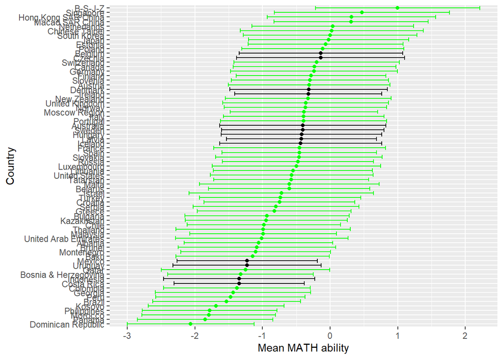

```r
# add CNT to PV_MATH_IRT
data_CNT <- data %>%
  select(CNTSTUID, CNT)
colnames(data_CNT)[colnames(data_CNT) == "CNTSTUID"] <- "person_id"
PV_MATH_c <- merge(PV_MATH_c, data_CNT, by = "person_id")

# take country mean
PV_MATH_mean_c <- PV_MATH_c %>% group_by(CNT) %>%
  summarize(mean1 = mean(PV1), mean2 = mean(PV2),
            mean3 = mean(PV3), mean4 = mean(PV4),
            mean5 = mean(PV5), mean6 = mean(PV6),
            mean7 = mean(PV7), mean8 = mean(PV8),
            mean9 = mean(PV9), mean10 = mean(PV10),
            sd1 = sd(PV1), sd2 = sd(PV2),
            sd3 = sd(PV3), sd4 = sd(PV4),
            sd5 = sd(PV5), sd6 = sd(PV6),
            sd7 = sd(PV7), sd8 = sd(PV8),
            sd9 = sd(PV9), sd10 = sd(PV10)) %>%
  rowwise() %>%
  mutate(mean_MATH_c = mean(c(mean1, mean2, mean3, mean4, mean5,
                                mean6, mean7, mean8, mean9, mean10))) %>%
  mutate(sd_MATH_c = mean(c(sd1, sd2, sd3, sd4, sd5,
                              sd6, sd7, sd8, sd9, sd10)))

# make the current ranking based on the new ESCS
PV_MATH_mean_c <- PV_MATH_mean_c %>% arrange(desc(mean_MATH_c))
PV_MATH_mean_c$ourranking <- 1:nrow(PV_MATH_mean_c)
ranking_PV_MATH_mean_c <- PV_MATH_mean_c %>% select(CNT, ourranking)

# merge the ranking together with the "original" PISA ranking
rankings <- merge(ranking_MATH_mean, ranking_PV_MATH_mean_c, by = "CNT")

# add green color if rankings match
rankings <- rankings %>% mutate(color = ifelse(PISAranking == ourranking,
                                               "green", "black"))

# merge colors with the data
PV_MATH_mean_c <- merge(PV_MATH_mean_c, rankings, by = "CNT")

# Change country codes into country names
# KSV, QAZ, QCI, QMR, QRT, and TAP do not work with the function, so are coded seperately
PV_MATH_mean_c$CNT[PV_MATH_mean_c$CNT == "KSV"] <- "Kosovo"
PV_MATH_mean_c$CNT[PV_MATH_mean_c$CNT == "QAZ"] <- "Baku"
PV_MATH_mean_c$CNT[PV_MATH_mean_c$CNT == "QCI"] <- "B-S-J-Z"
PV_MATH_mean_c$CNT[PV_MATH_mean_c$CNT == "QMR"] <- "Moscow Region"
PV_MATH_mean_c$CNT[PV_MATH_mean_c$CNT == "QRT"] <- "Tatarstan"
PV_MATH_mean_c$CNT[PV_MATH_mean_c$CNT == "TAP"] <- "Chinese Taipei"
PV_MATH_mean_c$CNT[PV_MATH_mean_c$CNT != "Kosovo" & PV_MATH_mean_c$CNT != "Baku"
          & PV_MATH_mean_c$CNT != "B-S-J-Z" & PV_MATH_mean_c$CNT != "Moscow Region"
          & PV_MATH_mean_c$CNT != "Tatarstan" & PV_MATH_mean_c$CNT != "Chinese Taipei"] <-
  countrycode(PV_MATH_mean_c$CNT[PV_MATH_mean_c$CNT != "Kosovo" & PV_MATH_mean_c$CNT != "Baku"
              & PV_MATH_mean_c$CNT != "B-S-J-Z" & PV_MATH_mean_c$CNT != "Moscow Region"
              & PV_MATH_mean_c$CNT != "Tatarstan" & PV_MATH_mean_c$CNT != "Chinese Taipei"],
  "iso3c", "country.name")

# make the plot
ranking_plot_c <- ggplot(data = PV_MATH_mean_c, aes(x = mean_MATH_c,
                                y = reorder(CNT,mean_MATH_c), color = color)) +
  scale_color_identity() +
  geom_point() +
  geom_errorbar(aes(xmin = mean_MATH_c - sd_MATH_c,
                    xmax = mean_MATH_c + sd_MATH_c)) +
  xlab("Mean MATH ability") +
  ylab("Country")
ranking_plot_c
```

#### Create new ESCS (item level)

##### Recode data

Items should have 0 as their lowest value. Some items need to be recoded.

```r
# select all items needed for the IRT
ESCS_items <- data %>% select(CNT,
                              CNTSTUID,
                              ST005Q01TA,  # highest level of schooling completed by mother
                              ST006Q01TA:ST006Q04TA, # Does mother have this qualification?
                              ST007Q01TA,  # highest level of schooling completed by father
                              ST008Q01TA:ST008Q04TA, # Does father have this qualification?
                              OCOD1, # ISCO-08 occupational code mother
                              OCOD2, # ISCO-08 occupational code father
                              ST011Q01TA:ST011Q16NA, # Do you have this in your home?
                              ST011D17TA:ST011D19TA, # Do you have this in your home? CNT
                              ST012Q01TA:ST012Q09NA, # How many of this in your home?
                              ST013Q01TA             # How many books in your home?
                              ) %>% zap_labels()

# select binary variables to recode
data_binary <- ESCS_items %>% dplyr::select(ST006Q01TA:ST006Q04TA,
                                            ST008Q01TA:ST008Q04TA,
                                            ST011Q01TA:ST011Q16NA)

# Recode binary variables
ESCS_items <- ESCS_items %>% mutate_at(vars(all_of(colnames(data_binary))), list(~recode(., '1' = 1, '2' = 0)))

# select ST011 country specific variables
data_ST011_CS <- ESCS_items %>% dplyr::select(ST011D17TA:ST011D19TA)

# Make ST011 country specific variables numeric
ESCS_items[colnames(data_ST011_CS)] <- sapply(ESCS_items[colnames(data_ST011_CS)],as.numeric)
# make function to recode CS variables to 0, 1, NA
recode_CS <- function(var){
  var[var %% 2 == 0 & var < 9999996] <- 0
  var[var %% 2 == 1 & var < 9999996] <- 1
  var[var >= 9999997] <- NA
  return(var)
}

# apply function
ESCS_items[colnames(data_ST011_CS)] <- sapply(ESCS_items[colnames(data_ST011_CS)],recode_CS)

# select ST012 and ST013
data_rest <- ESCS_items %>% dplyr::select(ST012Q01TA:ST013Q01TA)

# make sure they have a 0 value
ESCS_items[colnames(data_rest)] <- ESCS_items[colnames(data_rest)] - 1

# make function to recode ST005 and ST007
recode_five <- function(var){
  var[var == 5] <- 0
  var[var == 4] <- 1
  var[var == 3] <- 2
  var[var == 2] <- 3
  var[var == 1] <- 4
  return(var)
}

# select ST005 and ST007
data_five <- ESCS_items %>% dplyr::select(ST005Q01TA, ST007Q01TA)

# apply function
ESCS_items[colnames(data_five)] <- sapply(ESCS_items[colnames(data_five)],recode_five)

# make OCO (occupation) variables into characters
ESCS_items$OCOD1 <- as.character(ESCS_items$OCOD1)
ESCS_items$OCOD2 <- as.character(ESCS_items$OCOD2)

# recode OCO values into categories
ESCS_items$OCOD1 <- ifelse(startsWith(ESCS_items$OCOD1, '0'), '0',
                      ifelse(startsWith(ESCS_items$OCOD1, '1'), '0',
                      ifelse(startsWith(ESCS_items$OCOD1, '2'), '1',
                      ifelse(startsWith(ESCS_items$OCOD1, '3'), '2',
                      ifelse(startsWith(ESCS_items$OCOD1, '4'), '3',
                      ifelse(startsWith(ESCS_items$OCOD1, '5'), '4',
                      ifelse(startsWith(ESCS_items$OCOD1, '6'), '5',
                      ifelse(startsWith(ESCS_items$OCOD1, '7'), '6',
                      ifelse(startsWith(ESCS_items$OCOD1, '8'), '6',
                      ifelse(startsWith(ESCS_items$OCOD1, '9'), '6',
                             NA))))))))))

ESCS_items$OCOD2 <- ifelse(startsWith(ESCS_items$OCOD2, '0'), '0',
                      ifelse(startsWith(ESCS_items$OCOD2, '1'), '0',
                      ifelse(startsWith(ESCS_items$OCOD2, '2'), '1',
                      ifelse(startsWith(ESCS_items$OCOD2, '3'), '2',
                      ifelse(startsWith(ESCS_items$OCOD2, '4'), '3',
                      ifelse(startsWith(ESCS_items$OCOD2, '5'), '4',
                      ifelse(startsWith(ESCS_items$OCOD2, '6'), '5',
                      ifelse(startsWith(ESCS_items$OCOD2, '7'), '6',
                      ifelse(startsWith(ESCS_items$OCOD2, '8'), '6',
                      ifelse(startsWith(ESCS_items$OCOD2, '9'), '6',
                             NA))))))))))

# code back to numeric
ESCS_items$OCOD1 <- as.numeric(ESCS_items$OCOD1)
ESCS_items$OCOD2 <- as.numeric(ESCS_items$OCOD2)
```

##### Create useful dataset

```r
# make long format dataset
ESCS_items_long <- ESCS_items %>% pivot_longer(cols = ST005Q01TA:ST013Q01TA,
                                               names_to = "item",
                                                    values_to = "item_score")
# create variable item_id
ESCS_items_long$item_id <- ESCS_items_long$item

# change name to person_id
colnames(ESCS_items_long)[colnames(ESCS_items_long) == 'CNTSTUID'] <- 'person_id'

# give some variables an unique item_id per country (CS = country specific)
items_CS <- ESCS_items %>%
  select(ST006Q03TA, ST006Q04TA, ST007Q01TA, ST008Q03TA, ST008Q04TA, ST011D17TA, ST011D18TA, ST011D19TA, ST012Q01TA, ST012Q02TA) %>%
  colnames()

for(var in items_CS){
  ESCS_items_long$item_id[ESCS_items_long$item_id == var] <- paste(
                                    ESCS_items_long$item[ESCS_items_long$item_id == var],
                                    ESCS_items_long$CNT[ESCS_items_long$item_id == var],
                                    sep = "_")
}

# drop the items where a score is missing
ESCS_items_long_complete <- ESCS_items_long %>% drop_na(item_score)

# select variables to put into IRT as responses
responses <- ESCS_items_long_complete %>% dplyr::select(person_id, item_id, item_score)

# remove items that either have only value 0 or do not have value 0
`%notin%` <- Negate(`%in%`)
baddies <- c("ST006Q03TA_POL", "ST008Q03TA_POL", "ST005Q01TA_CAN", "ST005Q01TA_JPN", "ST005Q01TA_POL", "ST007Q01TA_CAN", "ST007Q01TA_JPN","ST007Q01TA_POL")
responses <- responses %>%
  filter(item_id %notin% baddies)

# remove items with an alpha between -0.1 and 0.1
baddies2 <- c("ST011Q08TA_PAN", "ST006Q04TA_KAZ", "ST008Q04TA_NZL", "ST011D17TA_SVN", "ST007Q01TA_KSV", "ST012Q01TA_FRA", "ST012Q01TA_LUX", "ST012Q01TA_SVN", "ST008Q04TA_QAZ", "ST012Q01TA_NZL", "ST006Q04TA_POL", "ST008Q04TA_QRT", "ST006Q04TA_RUS", "ST008Q04TA_DEU", "ST012Q01TA_AUS", "ST011D18TA_AUT", "ST012Q01TA_TAP", "ST012Q01TA_IRL", "ST008Q04TA_ROU", "ST008Q03TA_DNK", "ST012Q01TA_HUN", "ST006Q04TA_NZL", "ST006Q04TA_FIN", "ST006Q04TA_ROU", "ST008Q04TA_KAZ", "ST012Q01TA_GBR", "ST012Q01TA_DNK", "ST012Q01TA_BEL", "ST008Q03TA_JPN", "ST008Q04TA_QMR", "ST006Q03TA_UKR", "ST008Q04TA_RUS", "ST012Q01TA_ISL", "ST012Q01TA_MLT", "ST006Q04TA_DEU", "ST006Q04TA_QRT", "ST012Q01TA_NLD", "ST008Q03TA_UKR", "ST008Q04TA_ISL", "ST012Q01TA_ESP", "ST012Q01TA_SWE", "ST011D19TA_LUX", "ST012Q01TA_USA", "ST011Q08TA_PER", "OCOD2_r_ARE", "ST008Q04TA_POL", "OCOD2_r_QAT", "ST006Q04TA_QAZ", "ST012Q01TA_KOR", "ST012Q01TA_DEU", "ST012Q02TA_JPN", "ST012Q01TA_CAN", "ST008Q03TA_HRV", "ST012Q01TA_ITA", "ST008Q03TA_BLR", "ST012Q01TA_FIN", "ST012Q01TA_ISR", "ST012Q01TA_POL", "ST012Q01TA_AUT", "ST008Q04TA_NOR")
responses <- responses %>%
  filter(item_id %notin% baddies2)
```

##### Run IRT

```r
# estimate the parameters
parms_2PL <- dexterMML::fit_2pl(responses)
```

```
## The EM solution has a lower accuracy (~0.00013). Reasons: maximum iterations reached. See the section 'troubleshooting' in the help documentation for possible solutions.
```

```r
coef <- coef(parms_2PL)
```

##### Plot beta values

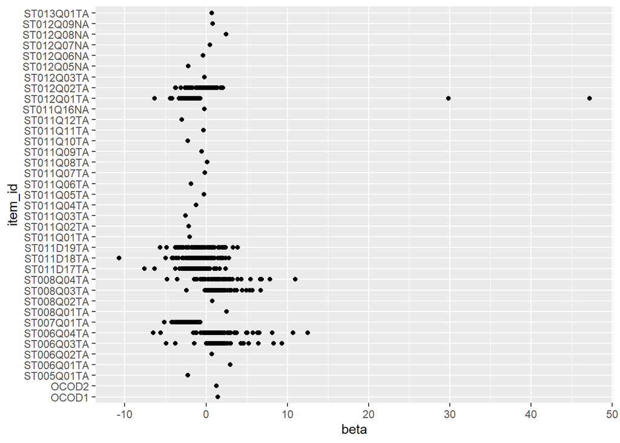

```r
# split item_id into item and country (so we can plot per item)
coef$item_id <- strsplit(coef$item_id, '_')
coef$CNT <- sapply(coef$item_id, function(x) x[length(x)])
coef$item_id <- sapply(coef$item_id, function(x) x[1])

# make a variable for max score per item
coef <- coef %>% group_by(item_id) %>% mutate(max_score=max(item_score))

# keep only the betas of the items where the item score is the max score
coef2 <- coef[coef$item_score == coef$max_score,]

# plot betas
beta_sd_plot <- ggplot(coef2, aes(x=beta, y=item_id)) + geom_point()
beta_sd_plot
```

##### Get estimate for ESCS

```r
# estimate ESCS
theta <- dexterMML::ability.mml(responses, parms_2PL, method = "WLE")
# change name of person_id to CNTSTUID so we can match on it
colnames(theta) <- c("CNTSTUID", "ESCS_IRT", "SE_ESCS_IRT")

# add ESCS to the dataset
data <- merge(data, theta, by = "CNTSTUID")

# check if ESCS_IRT is in the data
summary(data$ESCS_IRT)
```

```
##      Min.   1st Qu.    Median      Mean   3rd Qu.      Max.      NA's
## -12.14723  -0.70390   0.01586  -0.01249   0.70086  12.16763         6
```

#### Create new MATH (item level)

```r
# load database
pisa18_m <- readRDS("../data/pisa18_m.RDS")

# invest database
head(pisa18_m)
```

```
## # A tibble: 6 × 33
##   CNT        CNTSCHID CNTSTUID BOOKID  item_id response item_score response_time
##   <chr+lbl>     <dbl>    <dbl> <dbl+l> <chr>   <fct>         <dbl>         <dbl>
## 1 ALB [Alba…   800115   800001 5 [For… M909Q01 1 - Ful…          1         45211
## 2 ALB [Alba…   800115   800001 5 [For… M909Q02 No cred…          0         42507
## 3 ALB [Alba…   800115   800001 5 [For… M909Q03 0 - No …          0         34071
## 4 ALB [Alba…   800115   800001 5 [For… M949Q01 Full cr…          1         38469
## 5 ALB [Alba…   800115   800001 5 [For… M949Q02 Full cr…          1         35527
## 6 ALB [Alba…   800115   800001 5 [For… M949Q03 2 - Ful…          2         70079
## # ℹ 25 more variables: SUBNATIO <chr+lbl>, ST004D01T <dbl+lbl>,
## #   ST019AQ01T <dbl+lbl>, ST127Q03TA <dbl+lbl>, IMMIG <dbl+lbl>,
## #   ESCS <dbl+lbl>, EFFORT1 <dbl+lbl>, EFFORT2 <dbl+lbl>, PROGN <chr+lbl>,
## #   W_FSTUWT <dbl>, PV1MATH <dbl>, PV2MATH <dbl>, PV3MATH <dbl>, PV4MATH <dbl>,
## #   PV5MATH <dbl>, PV6MATH <dbl>, PV7MATH <dbl>, PV8MATH <dbl>, PV9MATH <dbl>,
## #   PV10MATH <dbl>, cluster <chr>, sequence_in_cluster <chr>, item_type <chr>,
## #   content <chr>, cluster_positie <int>
```

```r
# select all plausible values of reading and the new ESCS
data_read <- data %>%
  select(CNTSTUID, ESCS_IRT, starts_with("PV")) %>%
  select(CNTSTUID, ESCS_IRT, ends_with("READ"))

# merge with cognitive data
pisa18_m <- merge(pisa18_m, data_read, by = "CNTSTUID")

# prepare for plausible_values()
colnames(pisa18_m)[colnames(pisa18_m) == "CNTSTUID"] <- "person_id"
colnames(pisa18_m)[colnames(pisa18_m) == "BOOKID"] <- "booklet_id"
pisa18_responses <- pisa18_m %>%
  select(person_id, item_id, item_score, booklet_id, ESCS_IRT, PV1READ) %>%
  drop_na(item_score) %>%
  unique()

# compute plausible values
PV_MATH_IRT <- dexter::plausible_values(pisa18_responses, covariates = c("ESCS_IRT", "PV1READ"), nPV = 10)
```

#### Regression new ESCS (item level)

```r
# create 10 SEM models
model1_IRT <- "
PV1 ~ 1 + ESCS_IRT
"

model2_IRT <- "
PV2 ~ 1 + ESCS_IRT
"

model3_IRT <- "
PV3 ~ 1 + ESCS_IRT
"

model4_IRT <- "
PV4 ~ 1 + ESCS_IRT
"

model5_IRT <- "
PV5 ~ 1 + ESCS_IRT
"

model6_IRT <- "
PV6 ~ 1 + ESCS_IRT
"

model7_IRT <- "
PV7 ~ 1 + ESCS_IRT
"

model8_IRT <- "
PV8 ~ 1 + ESCS_IRT
"

model9_IRT <- "
PV9 ~ 1 + ESCS_IRT
"

model10_IRT <- "
PV10 ~ 1 + ESCS_IRT
"

models_IRT <- c(model1_IRT, model2_IRT, model3_IRT, model4_IRT, model5_IRT, model6_IRT,
                model7_IRT, model8_IRT, model9_IRT, model10_IRT)
reg_coef_IRT <- c(rep(0,10))
p_value_IRT <- c(rep(0,10))

# fit SEM models
for(model in models_IRT){
  fit <- sem(model, data=PV_MATH_IRT)
  B <- summary(fit)[[5]]$est[2] # regression coefficient
  P <- summary(fit)[[5]]$pvalue[2] # pvalue
  reg_coef_IRT[match(model,models_IRT)] <- B
  p_value_IRT[match(model,models_IRT)] <- P
}

# mean regression coefficient
mean(reg_coef_IRT)
```

```
## [1] 0.4362316
```

```r
# mean p-value
mean(p_value_IRT)
```

```
## [1] 0
```

#### Ranking of countries on MATH using new ESCS (item level)

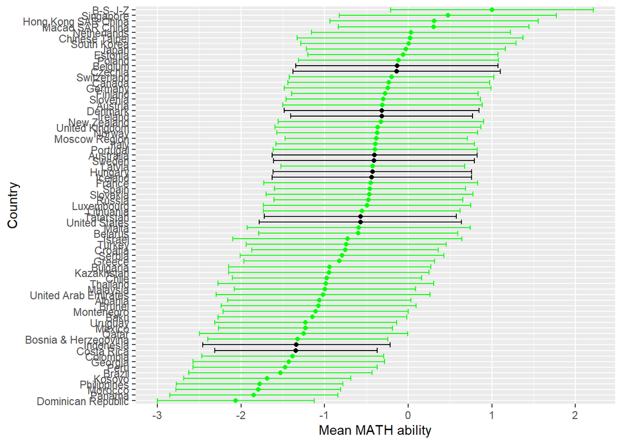

```r
# add CNT to PV_MATH_IRT
data_CNT <- data %>%
  select(CNTSTUID, CNT)
colnames(data_CNT)[colnames(data_CNT) == "CNTSTUID"] <- "person_id"
PV_MATH_IRT <- merge(PV_MATH_IRT, data_CNT, by = "person_id")

# take country mean
PV_MATH_mean_IRT <- PV_MATH_IRT %>% group_by(CNT) %>%
  summarize(mean1 = mean(PV1), mean2 = mean(PV2),
            mean3 = mean(PV3), mean4 = mean(PV4),
            mean5 = mean(PV5), mean6 = mean(PV6),
            mean7 = mean(PV7), mean8 = mean(PV8),
            mean9 = mean(PV9), mean10 = mean(PV10),
            sd1 = sd(PV1), sd2 = sd(PV2),
            sd3 = sd(PV3), sd4 = sd(PV4),
            sd5 = sd(PV5), sd6 = sd(PV6),
            sd7 = sd(PV7), sd8 = sd(PV8),
            sd9 = sd(PV9), sd10 = sd(PV10)) %>%
  rowwise() %>%
  mutate(mean_MATH_IRT = mean(c(mean1, mean2, mean3, mean4, mean5,
                                mean6, mean7, mean8, mean9, mean10))) %>%
  mutate(sd_MATH_IRT = mean(c(sd1, sd2, sd3, sd4, sd5,
                              sd6, sd7, sd8, sd9, sd10)))

# make the current ranking based on the new ESCS
PV_MATH_mean_IRT <- PV_MATH_mean_IRT %>% arrange(desc(mean_MATH_IRT))
PV_MATH_mean_IRT$ourranking <- 1:nrow(PV_MATH_mean_IRT)
ranking_PV_MATH_mean_IRT <- PV_MATH_mean_IRT %>% select(CNT, ourranking)

# merge the rankings together with the "original" ranking
rankings <- merge(ranking_MATH_mean, ranking_PV_MATH_mean_IRT, by = "CNT")

# merge the two rankings together
rankings <- merge(ranking_MATH_mean, ranking_PV_MATH_mean_IRT, by = "CNT")

# add green color if rankings match
rankings <- rankings %>% mutate(color = ifelse(PISAranking == ourranking,
                                               "green", "black"))

# merge colors with the data
PV_MATH_mean_IRT <- merge(PV_MATH_mean_IRT, rankings, by = "CNT")

# Change country codes into country names
# KSV, QAZ, QCI, QMR, QRT, and TAP do not work with the function, so are coded seperately
PV_MATH_mean_IRT$CNT[PV_MATH_mean_IRT$CNT == "KSV"] <- "Kosovo"
PV_MATH_mean_IRT$CNT[PV_MATH_mean_IRT$CNT == "QAZ"] <- "Baku"
PV_MATH_mean_IRT$CNT[PV_MATH_mean_IRT$CNT == "QCI"] <- "B-S-J-Z"
PV_MATH_mean_IRT$CNT[PV_MATH_mean_IRT$CNT == "QMR"] <- "Moscow Region"
PV_MATH_mean_IRT$CNT[PV_MATH_mean_IRT$CNT == "QRT"] <- "Tatarstan"
PV_MATH_mean_IRT$CNT[PV_MATH_mean_IRT$CNT == "TAP"] <- "Chinese Taipei"
PV_MATH_mean_IRT$CNT[PV_MATH_mean_IRT$CNT != "Kosovo" & PV_MATH_mean_IRT$CNT != "Baku"
          & PV_MATH_mean_IRT$CNT != "B-S-J-Z" & PV_MATH_mean_IRT$CNT != "Moscow Region"
          & PV_MATH_mean_IRT$CNT != "Tatarstan" & PV_MATH_mean_IRT$CNT != "Chinese Taipei"] <-
  countrycode(PV_MATH_mean_IRT$CNT[PV_MATH_mean_IRT$CNT != "Kosovo" & PV_MATH_mean_IRT$CNT != "Baku"
              & PV_MATH_mean_IRT$CNT != "B-S-J-Z" & PV_MATH_mean_IRT$CNT != "Moscow Region"
              & PV_MATH_mean_IRT$CNT != "Tatarstan" & PV_MATH_mean_IRT$CNT != "Chinese Taipei"],
  "iso3c", "country.name")

# make the plot
ranking_plot_IRT <- ggplot(data = PV_MATH_mean_IRT, aes(x = mean_MATH_IRT,
                                y = reorder(CNT,mean_MATH_IRT), color = color)) +
  scale_color_identity() +
  geom_point() +
  geom_errorbar(aes(xmin = mean_MATH_IRT - sd_MATH_IRT,
                    xmax = mean_MATH_IRT + sd_MATH_IRT)) +
  xlab("Mean MATH ability") +
  ylab("Country")
ranking_plot_IRT
```

#### Correlation between original and new MATH (per country)

```r
# create dataframes for correlation
data_cor_c <- data.frame(MATH_c = PV_MATH_mean_c$mean_MATH_c,
                         CNT = PV_MATH_mean_c$CNT)
data_cor_orig <- data.frame(MATH = MATH_mean$mean_MATH,
                            CNT = MATH_mean$CNT)
data_cor_IRT <- data.frame(MATH_IRT = PV_MATH_mean_IRT$mean_MATH_IRT,
                           CNT = PV_MATH_mean_IRT$CNT)
data_cor1 <- merge(data_cor_c, data_cor_orig, by = "CNT")
data_cor2 <- merge(data_cor_IRT, data_cor_orig, by = "CNT")

# indicator level
cor(data_cor1$MATH, data_cor1$MATH_c)
```

```
## [1] 0.9999734
```

```r
# item level
cor(data_cor2$MATH, data_cor2$MATH_IRT)
```

```
## [1] 0.9999795
```

#### Correlation between new ESCS and new MATH

```r
# original
cor1 <- cor(PV_MATH$PV1, PV_MATH$ESCS, use = "pairwise.complete.obs")
cor2 <- cor(PV_MATH$PV2, PV_MATH$ESCS, use = "pairwise.complete.obs")
cor3 <- cor(PV_MATH$PV3, PV_MATH$ESCS, use = "pairwise.complete.obs")
cor4 <- cor(PV_MATH$PV4, PV_MATH$ESCS, use = "pairwise.complete.obs")
cor5 <- cor(PV_MATH$PV5, PV_MATH$ESCS, use = "pairwise.complete.obs")
cor6 <- cor(PV_MATH$PV6, PV_MATH$ESCS, use = "pairwise.complete.obs")
cor7 <- cor(PV_MATH$PV7, PV_MATH$ESCS, use = "pairwise.complete.obs")
cor8 <- cor(PV_MATH$PV8, PV_MATH$ESCS, use = "pairwise.complete.obs")
cor9 <- cor(PV_MATH$PV9, PV_MATH$ESCS, use = "pairwise.complete.obs")
cor10 <- cor(PV_MATH$PV10, PV_MATH$ESCS, use = "pairwise.complete.obs")
meancor <- mean(c(cor1, cor2, cor3, cor4, cor5, cor6, cor7, cor8, cor9, cor10))
meancor
```

```
## [1] 0.3514424
```

```r
# indicator level
cor1_c <- cor(PV_MATH_c$PV1, PV_MATH_c$ESCS_c)
cor2_c <- cor(PV_MATH_c$PV2, PV_MATH_c$ESCS_c)
cor3_c <- cor(PV_MATH_c$PV3, PV_MATH_c$ESCS_c)
cor4_c <- cor(PV_MATH_c$PV4, PV_MATH_c$ESCS_c)
cor5_c <- cor(PV_MATH_c$PV5, PV_MATH_c$ESCS_c)
cor6_c <- cor(PV_MATH_c$PV6, PV_MATH_c$ESCS_c)
cor7_c <- cor(PV_MATH_c$PV7, PV_MATH_c$ESCS_c)
cor8_c <- cor(PV_MATH_c$PV8, PV_MATH_c$ESCS_c)
cor9_c <- cor(PV_MATH_c$PV9, PV_MATH_c$ESCS_c)
cor10_c <- cor(PV_MATH_c$PV10, PV_MATH_c$ESCS_c)
meancor_c <- mean(c(cor1_c, cor2_c, cor3_c, cor4_c, cor5_c, cor6_c, cor7_c, cor8_c, cor9_c, cor10_c))
meancor_c
```

[output not shown]

```r
# item level
cor1_IRT <- cor(PV_MATH_IRT$PV1, PV_MATH_IRT$ESCS_IRT, use = "pairwise.complete.obs")
cor2_IRT <- cor(PV_MATH_IRT$PV2, PV_MATH_IRT$ESCS_IRT, use = "pairwise.complete.obs")
cor3_IRT <- cor(PV_MATH_IRT$PV3, PV_MATH_IRT$ESCS_IRT, use = "pairwise.complete.obs")
cor4_IRT <- cor(PV_MATH_IRT$PV4, PV_MATH_IRT$ESCS_IRT, use = "pairwise.complete.obs")
cor5_IRT <- cor(PV_MATH_IRT$PV5, PV_MATH_IRT$ESCS_IRT, use = "pairwise.complete.obs")
cor6_IRT <- cor(PV_MATH_IRT$PV6, PV_MATH_IRT$ESCS_IRT, use = "pairwise.complete.obs")
cor7_IRT <- cor(PV_MATH_IRT$PV7, PV_MATH_IRT$ESCS_IRT, use = "pairwise.complete.obs")
cor8_IRT <- cor(PV_MATH_IRT$PV8, PV_MATH_IRT$ESCS_IRT, use = "pairwise.complete.obs")
cor9_IRT <- cor(PV_MATH_IRT$PV9, PV_MATH_IRT$ESCS_IRT, use = "pairwise.complete.obs")
cor10_IRT <- cor(PV_MATH_IRT$PV10, PV_MATH_IRT$ESCS_IRT, use = "pairwise.complete.obs")
meancor_IRT <- mean(c(cor1_IRT, cor2_IRT, cor3_IRT, cor4_IRT, cor5_IRT, cor6_IRT, cor7_IRT, cor8_IRT, cor9_IRT, cor10_IRT))
meancor_IRT
```

```
## [1] 0.3573433
```

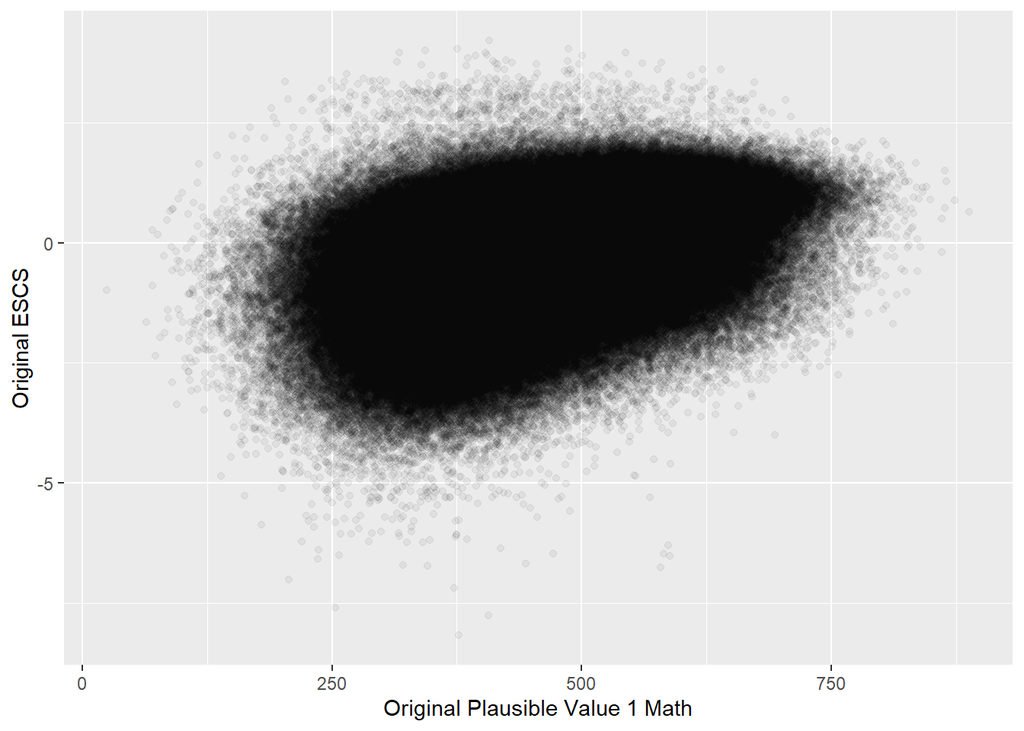

```r
# plot (only an estimation of the relation using the first plausible value
rela_math_escs_orig <- ggplot(data = data, aes(x = PV1MATH, y = ESCS)) +
  geom_point(alpha = 0.05) +
  ylab("Original ESCS") +
  xlab("Original Plausible Value 1 Math")
rela_math_escs_orig
```

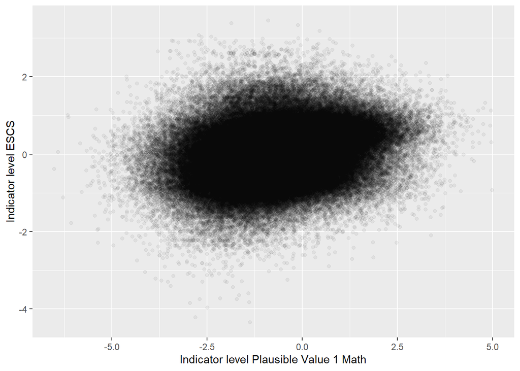

```r
rela_math_escs_c <- ggplot(data = PV_MATH_c, aes(x = PV1, y = ESCS_c)) +
  geom_point(alpha = 0.05) +
  ylab("Indicator level ESCS") +
  xlab("Indicator level Plausible Value 1 Math")
rela_math_escs_c
```

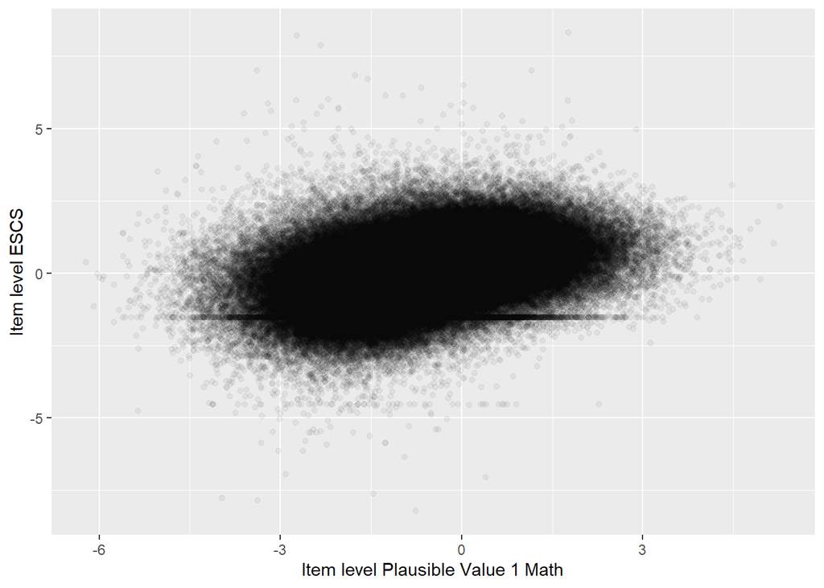

```r
rela_math_escs_irt <- ggplot(data = PV_MATH_IRT, aes(x = PV1, y = ESCS_IRT)) + geom_point(alpha = 0.05) +
  ylab("Item level ESCS") +
  xlab("Item level Plausible Value 1 Math")
rela_math_escs_irt
```

```r
# all look about linear, as expected
```